# Central Limit Theorem App

April 2, 2019

## Central Limit Theorem

In probability theory, the **central limit theorem** establishes that, in some situations, when independent random variables are added, their properly normalized sum tends toward a **normal distribution** even if the original variables themselves are not normally distributed.

The theorem is a key concept in probability theory because it implies that probabilistic and statistical methods that work for normal distributions can be applicable to many problems involving other types of distributions.

(source: Wikipedia)

## The App

- Our app demonstrates the central limit theorem **interactively** for the exponential distribution

PDF: f(x;λ) = λ*exp(-λ*x)

- The app simulates the distribution of averages of random samples of exponential distributions, and outputs the corresponding histogram.
- The exponential distribution is simulated in R with `rexp(n, lambda)` where `lambda` is the rate parameter and `n` the sample size.
- The histogram is produced using the ggplot2 data visualization package for R.

## User Input

The user can set:

- the value of the rate parameter λ
- the sample size

The user can choose to display over the histogram:

- the sample and theoretical means
- the probability density of the normal distribution

N(1/λ,1/λ*sqrt(1/n))

to which the distribution of sample averages approximates

## Example of Output

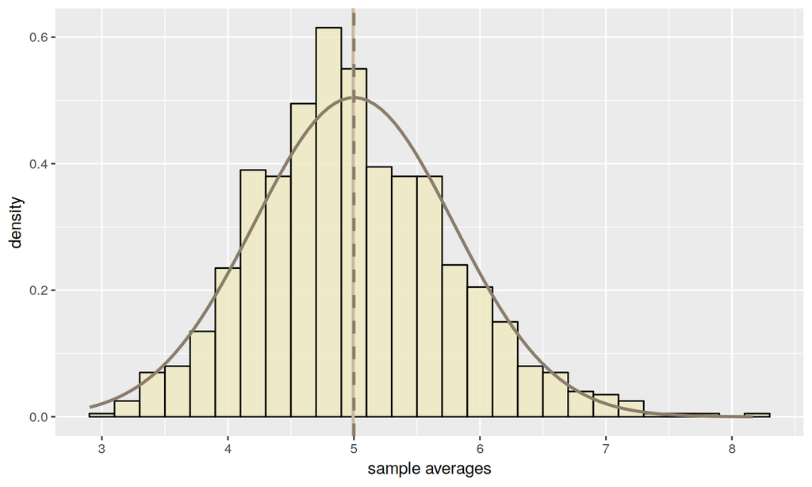